# xv20220712_S2_CCDs_z_score

x.vergara

2022-09-28

# Script to generate figure S2 in the short version of the paper.

Fig. S2: z-transformation and combining of replicate measurements of log2MMEJ:NHEJ values. A) Histogram of log2MMEJ:NHEJ balance of mock KO transfected samples of a single IPR (IPR_barcode: CATTTCTGATCAATAA). The fitted normal distribution is depicted in black. Mean (black) and mean ± one standard deviation (grey) highlighted with vertical dotted lines. In red, log2MMEJ:NHEJ balance of RAD50 KO is plotted as an example to illustrate the z-score transformation for a single protein. A red arrow is displayed connecting RAD50 KO data point in replicate #1 panel A and B. Each panel repre-sents a different replicate and a similar arrow could be drawn for the other replicates as well. B) Beeswarm plot of the z-score transformed log2MMEJ:NHEJ balance of KO samples for a single reporter (CATTTCTGATCAATAA) (Formula 4). C) z-score transformed log2MMEJ:NHEJ balance perturbations after combining three replicates for every MMEJ:NHEJ pathway reporters by the Stouffer’s method (Formula 5). A value outside the [-1.96,1.96] range is considered to be significant with a significance level of >95%. Positive values represent proteins that favor NHEJ (green dots and arrow) and negative values proteins that favor MMEJ (brown dots and arrow).

```r
knitr::opts_chunk$set(root.dir = '/home/x.vergara/XV_P3_ChromDSBScreen/xv_CRISPR_screen_figures/rmarkdown/xv20210920_paper_scripts/short_version/knit_html/')

StartTime <-Sys.time()
library(knitr)

# 8-digit Date tag:
Date <- substr(gsub("-","",Sys.time()),1,8)

#Change in.dir accordingly
in.dir <- "/home/x.vergara/XV_P3_ChromDSBScreen/xv_CRISPR_screen_figures/"

#Check if output contain datetag
saveRDS_proof <- function(object, file) {
  document_path <- rstudioapi::getSourceEditorContext()$path %>% str_split(pattern = "/") %>% unlist()
  document_name <- document_path[length(document_path)]
  sys_time <- Sys.time()
  if (grepl(Date, file) == T) {
    write(c(document_name, as.character(sys_time),"Output", correct_file), file = paste0(in.dir,"log"), ncolumns = 4, sep = "\t", append = T)
    saveRDS(object, file)
  }
  else {
    print("Incorrect datetag!")
  }
}

#Read rds check through different versions
readRDS_proof <- function(path, pat) {
  full.path <- paste0(in.dir, path)
  document_path <- rstudioapi::getSourceEditorContext()$path %>% str_split(pattern = "/") %>% unlist()
  document_name <- document_path[length(document_path)]
  sys_time <- Sys.time()

  if(file.exists(full.path) == T){
    if(paste0(in.dir,path) != getwd()){
      setwd(paste0(in.dir, path))
  }
    file.list <- list.files(pattern = pat)
    correct_file <- str_sort(file.list, decreasing = T)[1]
    print(correct_file)
    write(c(document_name,as.character(sys_time) ,"Input", correct_file), file = paste0(in.dir,"log"), ncolumns = 4, sep = "\t", append = T)
    readRDS(correct_file)

  }
  else{
  setwd(path)
  file.list <- list.files(pattern = pat)
  correct_file <- str_sort(file.list, decreasing = T)[1]
  print(correct_file)
  write(c(document_name, as.character(sys_time),"Input", correct_file),file = paste0(in.dir,"log"), ncolumns = 4, sep = "\t", append = T)
  readRDS(correct_file)
  }
}
```

# Libraries

```r
# libraries:
library(tidyverse)
library(ggrepel)
library(pheatmap)
library(rstatix)
library(stats)
library(tibble)
library(reshape2)
library(ggbeeswarm)
```

# Import data tables

```r
setwd(in.dir)

print("For this script the following data was inputed:")
```

```
## [1] "For this script the following data was inputed:"
```

```r
#Clone 5 chromatin Version cl20201026
clone5_z.score_chrom_tib <- readRDS_proof("/DATA/projects/DSBrepair/data/R","ChIP_zscore_selection")
```

```
## [1] "cl20220830_ChIP_zscore_selection.RDS"
```

```r
#Import MMEJ:NHEJ balance ratio measurements per replicate
ddr.screen.all.sel <- readRDS_proof( "data/processed_data/CCD_analysis","raw_data")
```

```
## [1] "xv20220819_screening_raw_data_repair_metrics.rds"
```

```r
#z-score replicate
fit.z.scores.ratio.IPR <- readRDS_proof( "data/processed_data/CCD_analysis","z_test_per_replicate")
```

```
## [1] "xv20220819_z_test_per_replicate_transformation.rds"
```

```r
#z-score replicate
fit.z.scores.ratio.mean <- readRDS_proof( "data/processed_data/CCD_analysis","z_test_final")
```

```
## [1] "xv20220819_z_test_final_values.rds"
```

```r
clone5_bc_cluster <-  c("CATCCACCACACTTCA","ATATCGTTGCTGGAGA","GTACCTCTCGATAGTG","TCTTTTGAGGAGCTGA","CATTTCTGATCAATAA","TGGCCAATATTTGTCT","ACTGTCGAGTTGTCCG","GAGCGCGTCACCGGGT","GCGCACCCTTTAATTG","ACCCCTAAAGGCGCTG","CGGCCTGAAGGTCAGG","AGAAAATAATATGACG","TTGAACGCGGGCTCGG","CCGGGGACGTATGCAC","GCTAACATCACGAATC","ATACTATATTTAACGG","TATGGCTGTCGGGTAG","AGGGCGTAAAATATTT","TGTCCCTTAGTACTTT")
```

#Supplementary Figures

#Figure S2A A) Histogram of log2MMEJ:NHEJ balance of mock KO transfected samples of a single IPR (IPR_barcode: CATTTCTGATCAATAA). The fitted normal distribution is depicted in black. Mean (black) and mean ± one standard deviation (grey) highlighted with vertical dotted lines. In red, log2MMEJ:NHEJ balance of RAD50 KO is plotted as an example to illustrate the z-score transformation for a single pro-tein. A red arrow is displayed connecting RAD50 KO data point in replicate #1 panel A and B. Each panel represents a different replicate and a similar arrow could be drawn for the other replicates as well.

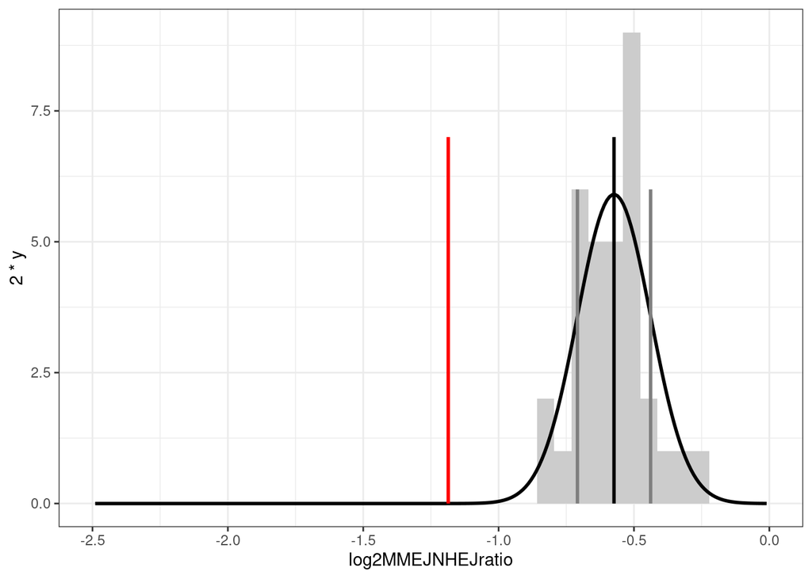

```r
#Create normal distribution
range_to_plot <- seq(-4,2,0.01)

#Normal distribution for the example
normal.parameters <- ddr.screen.all.sel %>% filter(sample == "WT") %>% filter(barcode == "CATTTCTGATCAATAA") %>% dplyr::group_by(rep) %>% dplyr::summarise(wt.log2MMEJNHEJratio = mean(log2MMEJNHEJratio, na.rm = T), sd.wt.log2MMEJNHEJratio = sd(log2MMEJNHEJratio, na.rm = T))
#Plot RAD50 KO example
RAD50KO_example <- ddr.screen.all.sel %>% filter(gene == "RAD50") %>% filter(barcode == "CATTTCTGATCAATAA")

distribution.R1 <- tibble(value = range_to_plot, y = dnorm(range_to_plot, mean = normal.parameters$wt.log2MMEJNHEJratio[1], sd = normal.parameters$sd.wt.log2MMEJNHEJratio[1]))
distribution.R2 <- tibble(value = range_to_plot, y = dnorm(range_to_plot, mean = normal.parameters$wt.log2MMEJNHEJratio[2], sd = normal.parameters$sd.wt.log2MMEJNHEJratio[2]))
distribution.R3 <- tibble(value = range_to_plot, y = dnorm(range_to_plot, mean = normal.parameters$wt.log2MMEJNHEJratio[3], sd = normal.parameters$sd.wt.log2MMEJNHEJratio[3]))

#Example data normalization
#Fitted curve (R1)
ggplot() +
  geom_histogram(data = ddr.screen.all.sel %>% filter(barcode == "CATTTCTGATCAATAA" & rep == "R1" & sample == "WT"), aes(log2MMEJNHEJratio), fill = "grey80", bins = 40) +
  geom_line(data = distribution.R1 %>% filter(value > -2.5 & value < 0), aes(value,2*y), color = "black", size = 1) +
  geom_segment(data = normal.parameters %>% filter(rep == "R1"), aes(x = wt.log2MMEJNHEJratio + sd.wt.log2MMEJNHEJratio, y = 0, xend = wt.log2MMEJNHEJratio + sd.wt.log2MMEJNHEJratio, yend = 6), color = "grey50", size = 1)  +
  geom_segment(data = normal.parameters %>% filter(rep == "R1"), aes(x = wt.log2MMEJNHEJratio - sd.wt.log2MMEJNHEJratio, y = 0, xend = wt.log2MMEJNHEJratio - sd.wt.log2MMEJNHEJratio, yend = 6), color = "grey50", size = 1) +
  geom_segment(data = normal.parameters %>% filter(rep == "R1"), aes(x = wt.log2MMEJNHEJratio, y = 0, xend = wt.log2MMEJNHEJratio, yend = 7), color = "black", size = 1) +
  geom_segment(data = RAD50KO_example %>% filter(rep == "R1"), aes(x = log2MMEJNHEJratio, y = 0, xend = log2MMEJNHEJratio, yend = 7), color = "red", size = 1) +
  theme_bw() + coord_cartesian(xlim = c(-2.5,0))
```

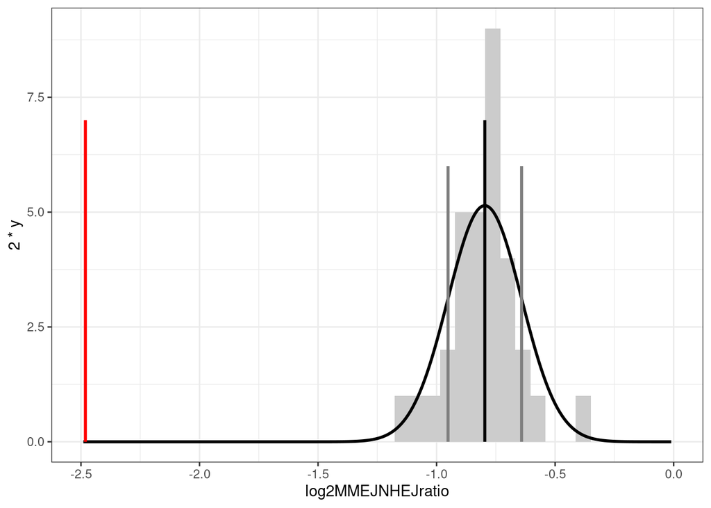

```r
#Step 1: Fitted curve (R4)
ggplot() +
  geom_histogram(data = ddr.screen.all.sel %>% filter(barcode == "CATTTCTGATCAATAA" & rep == "R2" & sample == "WT"), aes(log2MMEJNHEJratio), fill = "grey80", bins = 40) +
  geom_line(data = distribution.R2 %>% filter(value > -2.5 & value < 0), aes(value,2*y), color = "black", size = 1) +
  geom_segment(data = normal.parameters %>% filter(rep == "R2"), aes(x = wt.log2MMEJNHEJratio + sd.wt.log2MMEJNHEJratio, y = 0, xend = wt.log2MMEJNHEJratio + sd.wt.log2MMEJNHEJratio, yend = 6), color = "grey50", size = 1)  +
  geom_segment(data = normal.parameters %>% filter(rep == "R2"), aes(x = wt.log2MMEJNHEJratio - sd.wt.log2MMEJNHEJratio, y = 0, xend = wt.log2MMEJNHEJratio - sd.wt.log2MMEJNHEJratio, yend = 6), color = "grey50", size = 1) +
  geom_segment(data = normal.parameters %>% filter(rep == "R2"), aes(x = wt.log2MMEJNHEJratio, y = 0, xend = wt.log2MMEJNHEJratio, yend = 7), color = "black", size = 1) +
  geom_segment(data = RAD50KO_example %>% filter(rep == "R2"), aes(x = log2MMEJNHEJratio, y = 0, xend = log2MMEJNHEJratio, yend = 7), color = "red", size = 1) +
  theme_bw() + coord_cartesian(xlim = c(-2.5,0))
```

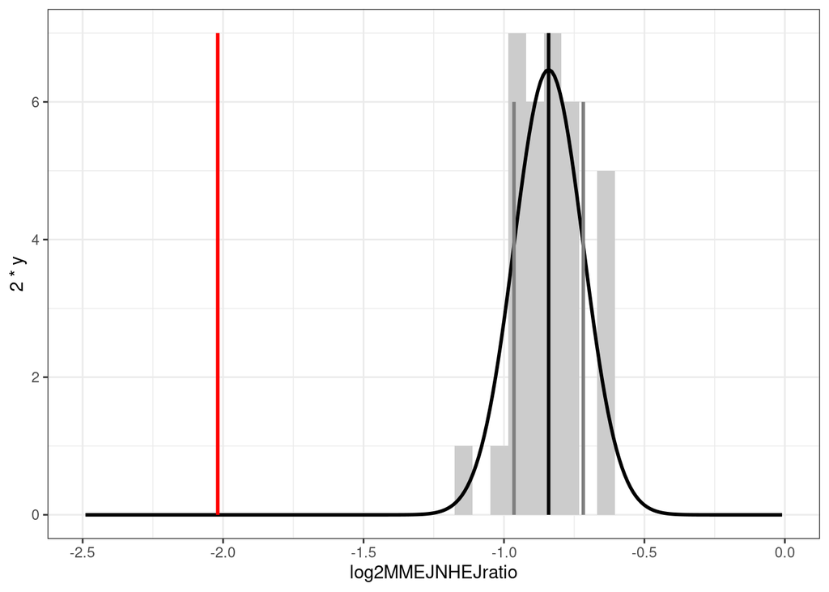

```r
#Step 1: Fitted curve (R5)
ggplot() +
  geom_histogram(data = ddr.screen.all.sel %>% filter(barcode == "CATTTCTGATCAATAA" & rep == "R3"& sample == "WT"), aes(log2MMEJNHEJratio), fill = "grey80", bins = 40) +
  geom_line(data = distribution.R3 %>% filter(value > -2.5 & value < 0), aes(value,2*y), color = "black", size = 1) +
  geom_segment(data = normal.parameters %>% filter(rep == "R3"), aes(x = wt.log2MMEJNHEJratio + sd.wt.log2MMEJNHEJratio, y = 0, xend = wt.log2MMEJNHEJratio + sd.wt.log2MMEJNHEJratio, yend = 6), color = "grey50", size = 1)  +
  geom_segment(data = normal.parameters %>% filter(rep == "R3"), aes(x = wt.log2MMEJNHEJratio - sd.wt.log2MMEJNHEJratio, y = 0, xend = wt.log2MMEJNHEJratio - sd.wt.log2MMEJNHEJratio, yend = 6), color = "grey50", size = 1) +
  geom_segment(data = normal.parameters %>% filter(rep == "R3"), aes(x = wt.log2MMEJNHEJratio, y = 0, xend = wt.log2MMEJNHEJratio, yend = 7), color = "black", size = 1) +
  geom_segment(data = RAD50KO_example %>% filter(rep == "R3"), aes(x = log2MMEJNHEJratio, y = 0, xend = log2MMEJNHEJratio, yend = 7), color = "red", size = 1) +
  theme_bw()  + coord_cartesian(xlim = c(-2.5,0))
```

#Figure S2B: Z-test for each replicate B) Beeswarm plot of the z-score transformed log2MMEJ:NHEJ balance of KO samples for a single re-porter (CATTTCTGATCAATAA) (Formula 4).

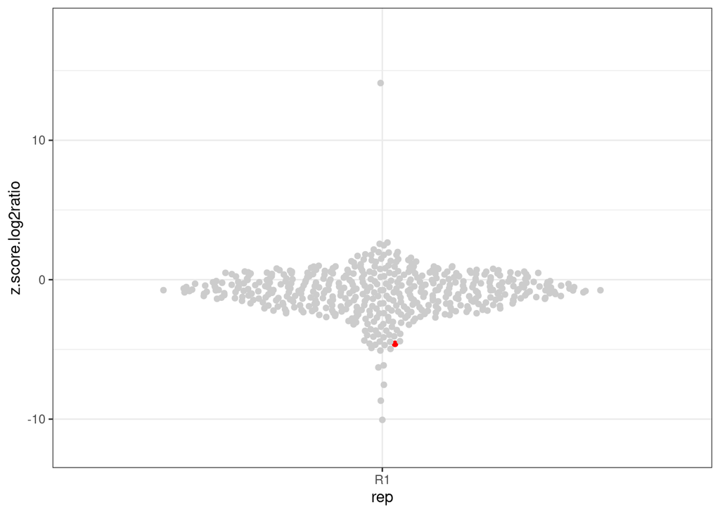

```r
example.barcode.z.scores <- fit.z.scores.ratio.IPR %>% filter(barcode == "CATTTCTGATCAATAA") %>% mutate(signif = case_when(z.score.log2ratio > 1.95 ~ "NHEJ", z.score.log2ratio < -1.95 ~ "MMEJ", T ~ "none"))

#R1
ggplot(example.barcode.z.scores %>% filter(rep == "R1" & sample == "KO")) +
  geom_quasirandom(aes(rep, z.score.log2ratio, color = gene == "RAD50")) + theme_bw() +
  scale_color_manual(values = c("grey80", "red")) +
  coord_cartesian(ylim = c(-12,18)) +
  scale_y_continuous(breaks = c(-10,0,10)) + theme(legend.position = "none")
```

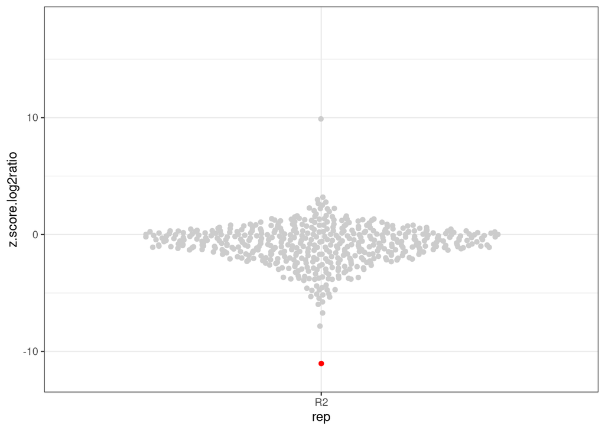

```r
#R2
ggplot(example.barcode.z.scores %>% filter(rep == "R2" & sample == "KO")) +
  geom_quasirandom(aes(rep, z.score.log2ratio, color = gene == "RAD50")) + theme_bw() +
  scale_color_manual(values = c("grey80", "red")) +
  coord_cartesian(ylim = c(-12,18)) +
  scale_y_continuous(breaks = c(-10,0,10)) + theme(legend.position = "none")
```

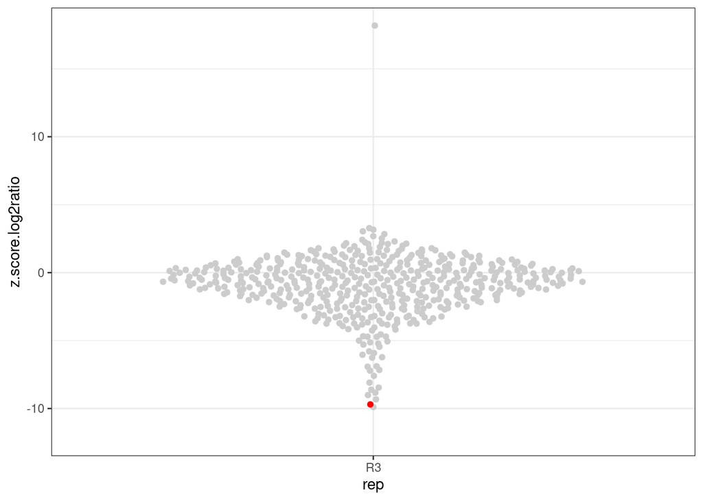

```r
#R3
ggplot(example.barcode.z.scores %>% filter(rep == "R3" & sample == "KO")) +
  geom_quasirandom(aes(rep, z.score.log2ratio, color = gene == "RAD50")) + theme_bw() +
  scale_color_manual(values = c("grey80", "red")) +
  coord_cartesian(ylim = c(-12,18)) +
  scale_y_continuous(breaks = c(-10,0,10)) + theme(legend.position = "none")
```

#Figure S2C: C) z-score transformed log2MMEJ:NHEJ balance perturbations after combining three replicates for eve-ry MMEJ:NHEJ pathway reporters by the Stouffer’s method (Formula 5). A value outside the [-1.96,1.96] range is considered to be significant with a significance level of >95%. Positive values rep-resent proteins that favor NHEJ (green dots and arrow) and negative values proteins that favor MMEJ (brown dots and arrow).

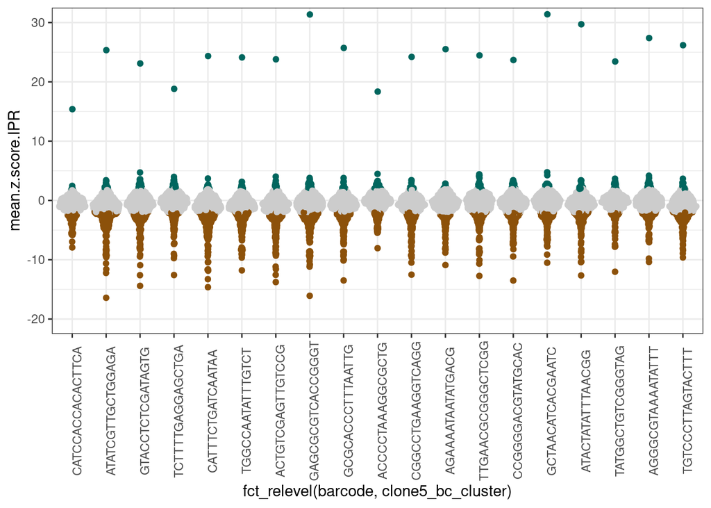

```r
all_barcodes_together <- fit.z.scores.ratio.mean %>% mutate(signif = case_when(mean.z.score.IPR > 1.95 ~ "NHEJ", mean.z.score.IPR < -1.95 ~ "MMEJ", T ~ "none"))

#R1
ggplot(all_barcodes_together %>% filter(sample == "KO")) +
  geom_quasirandom(aes(fct_relevel(barcode, clone5_bc_cluster), mean.z.score.IPR, color = signif)) + theme_bw() + scale_color_manual(values = c("#8c510a","#01665e","grey80")) +
  coord_cartesian(ylim = c(-20,30))  + theme(legend.position = "none", axis.text.x = element_text(angle = 90))
```